# Google Analytics for Tracking using R

Simona Grădinaru

### Introduction

Google Analytics data can be mined directly in R using **googleanalyticsR** package, allowing us to perform statistical analysis that would better understand, improve and later optimize website performance.

### Content

#### 1. Connect R and Google Analytics API.

#### 2. Data overview.

#### 3. Data visualization.

#### 4. Data insights.

### 1. Connect R and Google Analytics API.

```r
rerun_yn <- FALSE
if(rerun_yn == TRUE){

  # Connect R and Google Analytics
  ga_auth()

  # Generate a list of all the Google Analytics accounts you have access to
  ga_accounts <- ga_account_list()

  # ga_id contains the View ID for querying
  ga_id <- pull(ga_accounts[2,1])

  # Download all data and store it in a dataframe
  # blog was launched on September 11, 2020
  ga_df <- google_analytics(ga_id,
                            metrics = c("users", "sessions"),
                            dimensions = "date",
                            date_range = c("2020-09-11", as.character(Sys.Date()-1))
                            )

  # Obtain Google Analytics data by device category
  byDevice_df <- google_analytics(ga_id,
                                  date_range = c("2020-09-11", as.character(Sys.Date()-1)),
                                  metrics = c("sessions", "avgSessionDuration"),
                                  dimensions = c("date", "deviceCategory")
                                  )
}
```

### 2. Data overview.

Google's Basic visitor interaction model:

- **Visitor** — the client that visits the site, such as the browser or mobile phone operated by a person.
- **Session** — the period of time during which the visitor is active on the site.
- **Page** — activity on the user's behalf which sends a GIF request to the Analytics servers. This is typically characterized by a pageview, but it can include: a pageview or an event (e.g. click on a movie button).

### 2. Data overview.

Variables available in Google Analytics:

- Users, Sesssions, Page views
- Bounces (visitors who leave the website after visiting only one page)
- Devices used for visiting the website: desktop, mobile or tablet
- Users' location: continent and country
- Website traffic by channel (organic, social, direct)
- Campaign metrics
- Metrics by segments of users

### 3. Data visualization.

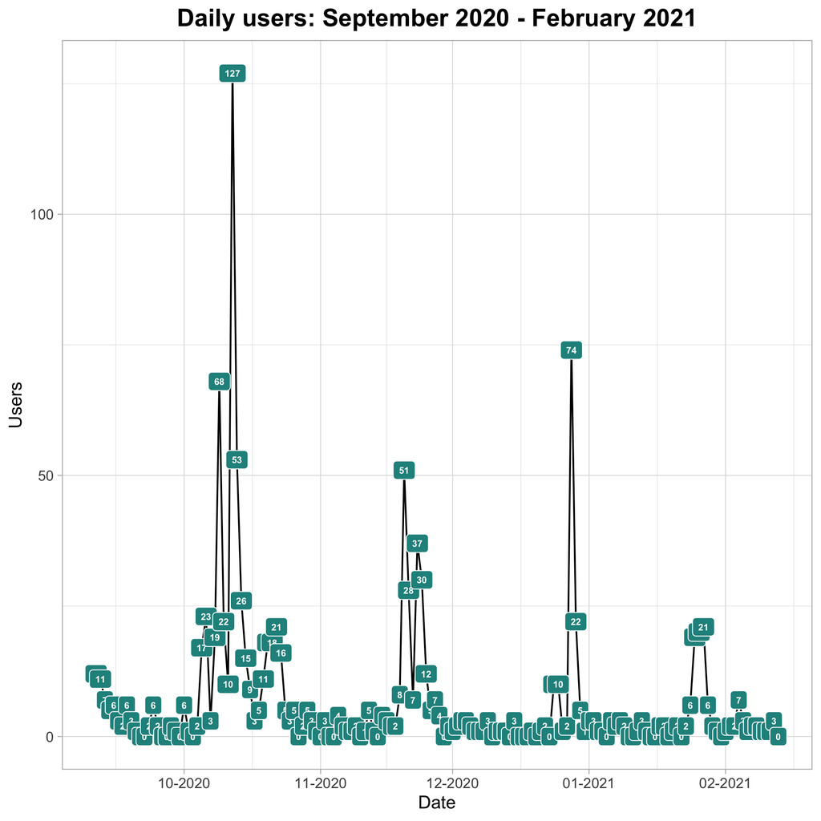

### Which are the most popular posts on my blog?

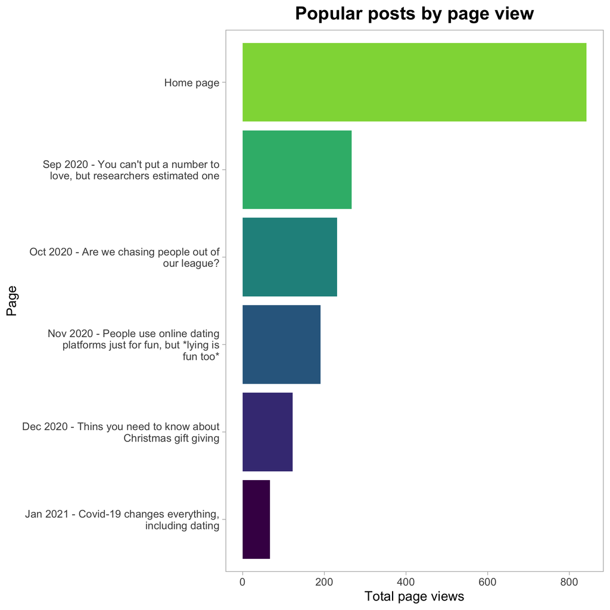

### When is the best time to publish posts?

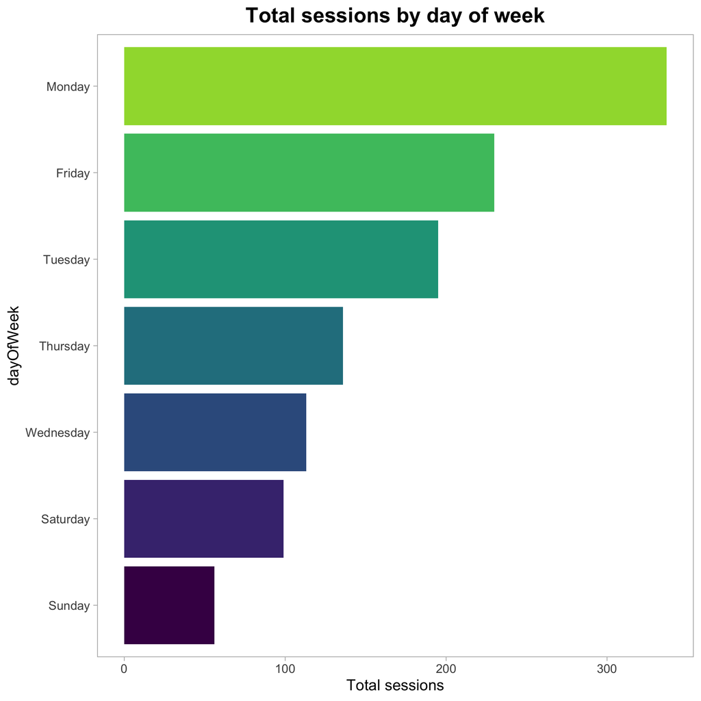

### What are the most frequent devices used for visiting the blog?

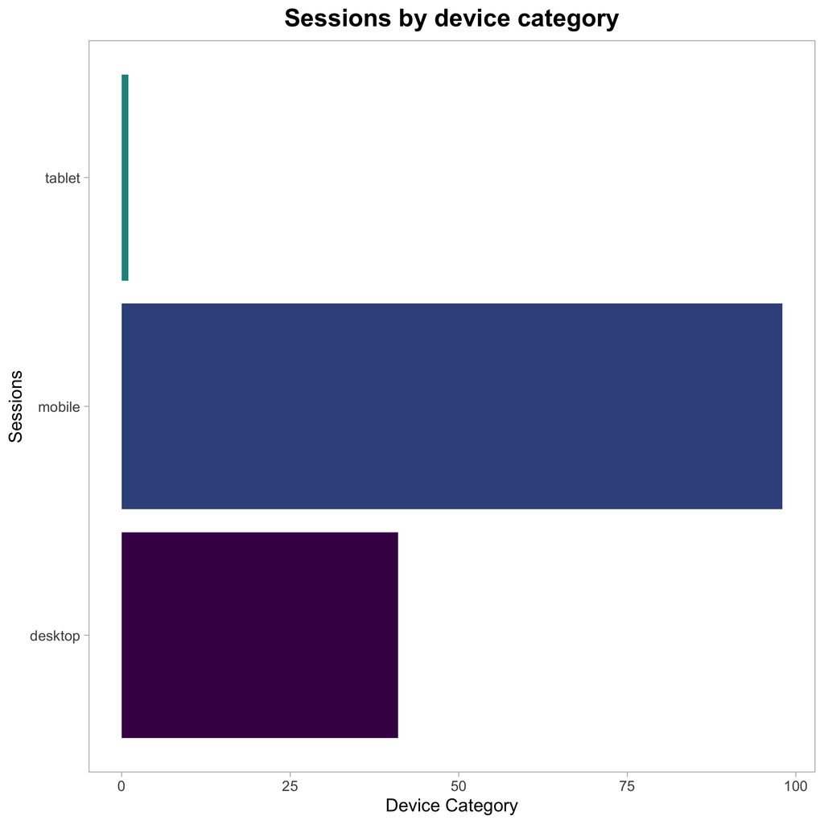

### What are the most frequent browsers used for visiting the blog?

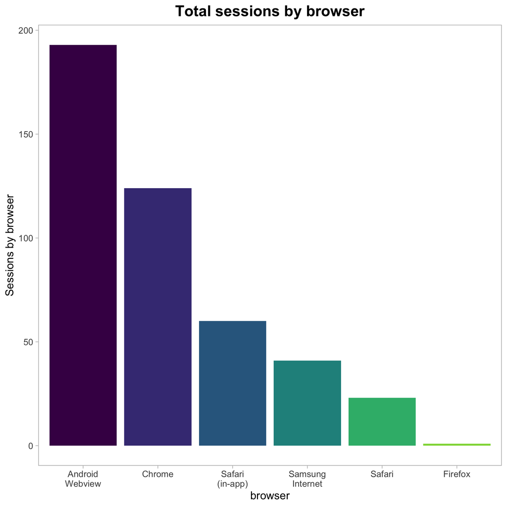

### What are the most frequent channels used for visiting the blog?

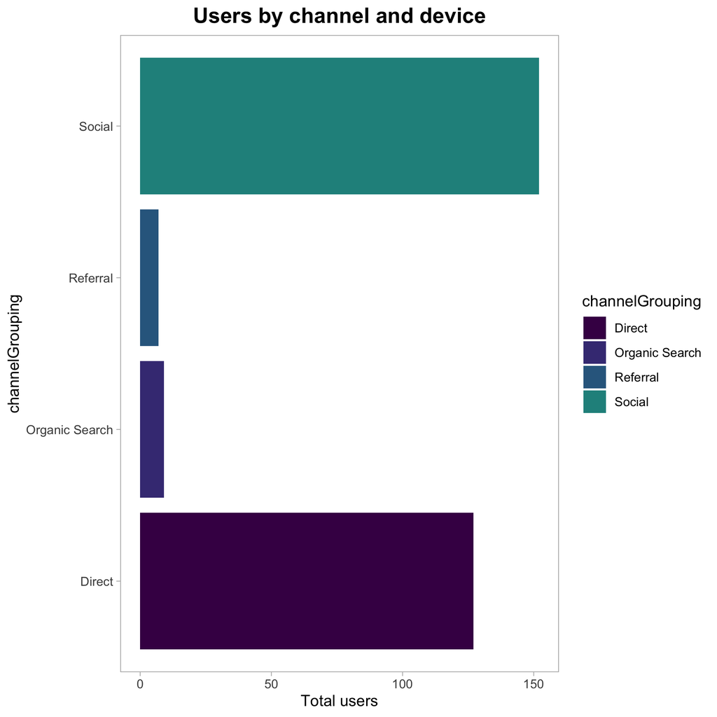

### Does social traffic comes from mobile devices?

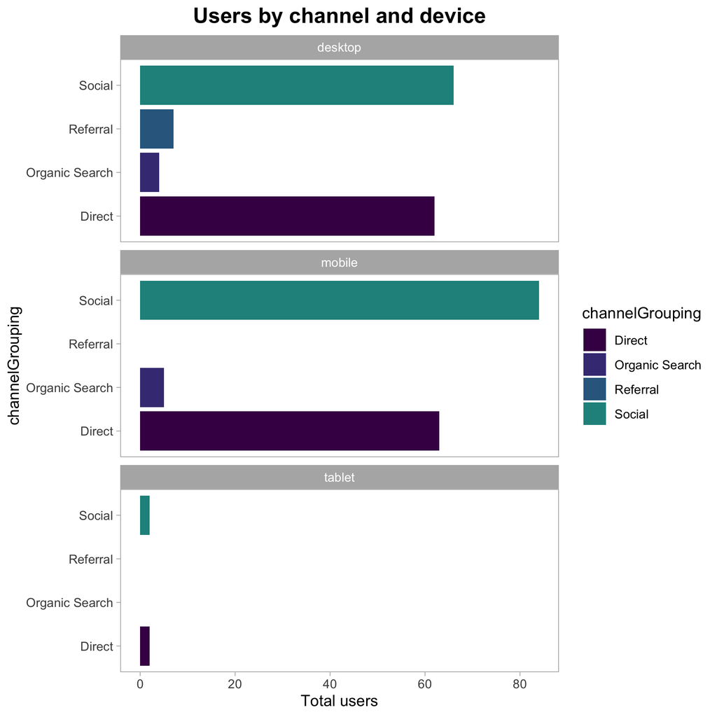

### Did my blog get any international exposure?

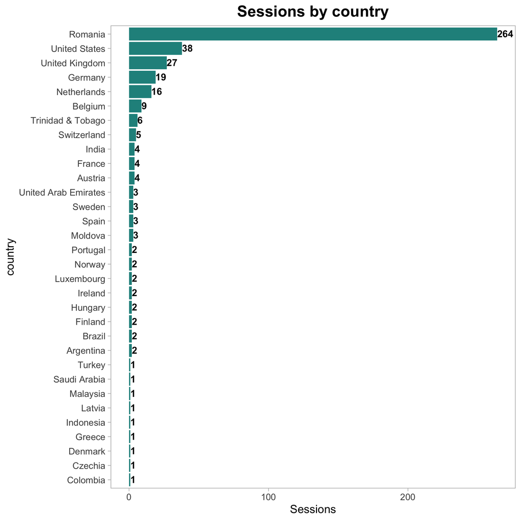

### 4. Data insights.

### Mobile vs desktop browsers

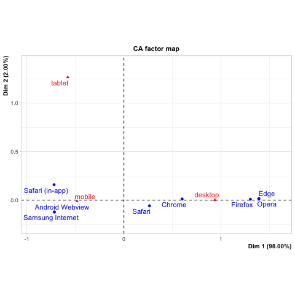

### When do people read more?

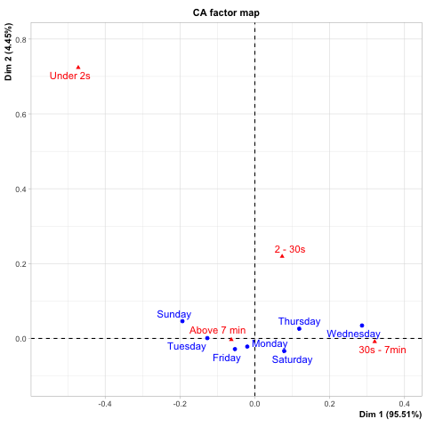

### Further steps

- Improve mobile user experience across all browsers
- Post on Monday or Friday
- Frequently share posts on social media
- Improve the home page for encouraging people to visit again the blog
- Keep blogging!